# Cosa guida il voto? Un’analisi dei risultati referendari tra demografia e storia elettorale

Report di Data Mining

Luca Oggioni, Filippo Valente, Enrico Pedol

Aprile 2026

# 1. Introduzione

La domanda di ricerca che ci siamo posti è: **Da cosa viene guidato il voto per comune?**

Il progetto si articola in quattro moduli:

- **Costruzione del Dataset e Data Quality**: integrazione di dati anagrafici (ISTAT), geografici e risultati storici (Eligendo), con imputazione dei valori mancanti tramite MICE.
- **Analisi Esplorativa (EDA)**: visualizzazioni, matrici di correlazione e individuazione di anomalie a livello comunale.
- **Modellistica Parametrica**: confronto tra Regressione Logistica classica, LASSO, Relaxed LASSO e Post-LASSO per la previsione dell’esito binario (vittoria del SÌ o del NO).
- **Modellistica Non Parametrica ed Ensemble**: Decision Tree, Random Forest e un modello surrogato globale per garantire spiegabilità (XAI).

# 2. Analisi Esplorativa-Descrittiva

## 2.1 Legenda delle Variabili

Il dataset è stato costruito unendo i dati demografici ISTAT (riferiti al 1° gennaio 2026) con i risultati elettorali Eligendo delle Elezioni Politiche del 2022 e del Referendum 2025, più i risultati del Referendum 22-23 marzo 2026. Per quest’ultimo, in virtù della mancata pubblicazione dei tabulati definitivi in formato strutturato, i dati sono stati estratti interrogando le **REST API interne** del portale ministeriale (`eleapi.interno.gov.it`), tramite lo script open-source del ricercatore **Lorenzo Ruffino** ([@Ruffino_Lorenzo](https://x.com/Ruffino_Lorenzo)), reso disponibile sul suo [repository GitHub](https://github.com/lorenzo-ruffino). Questo processo di *API scraping* ha permesso di ottenere i dati elettorali in un formato nativamente strutturato, superando i limiti della sola dashboard grafica ministeriale.

Di seguito il dizionario delle variabili:

- **Struttura base**:
  - `COMUNE`: Nome del comune
  - `CODICE_COMUNE`: Codice numerico ISTAT
  - `POSIZIONE_GEO`: 3 livelli (Nord, Centro, Sud)
- **Geometria e Demografia**:
  - `ETA_MEDIA`: Età media della popolazione
  - `PERC_MASCHILE`: Quota di residenti di sesso maschile
  - `POPOLAZIONE`: Numero totale dei residenti
  - `PERC_STRANIERI`: Quota di residenti di altra nazionalità
  - `SUPERFICIE_kmq`: Superficie in km²
  - `DENSITA_Xkmq`: `POPOLAZIONE`/`SUPERFICIE_kmq`
  - `FASCIA_POPOLAZIONE`: 4 livelli — “Micro” (<2.500 ab.), “Piccolo” (2.500–5.000), “Medio” (5.000–15.000), “Grande” (>15.000).
- **Istruzione**:
  - `BASSA_ISTR`: Quota di residenti con al massimo la licenza media
  - `MEDIA_ISTR`: Quota intermedia (= 1 − `ALTA_ISTR` − `BASSA_ISTR`)
  - `ALTA_ISTR`: Quota di residenti con titolo terziario di secondo livello o superiore
- **Reddito (Indici PCA)**: *Le tre variabili seguenti derivano da un’Analisi delle Componenti Principali applicata al set originario di fasce di reddito IRPEF (`REDDITO_MEDIO_0K_10K` fino a `REDDITO_MEDIO_120K_EPIU`). La PCA è stata adottata per risolvere il problema della quasi-perfetta multicollinearità tra queste fasce, le prime tre componenti estratte spiegano complessivamente il 62,6% della varianza originaria: un compromesso metodologico che sacrifica una quota di informazione per ottenere tre indicatori macro-economici stabili e ortogonali tra loro:*
  - `INDICE_POVERTA` (PC1): Cattura la diffusa assenza di redditi medi e alti, valori alti segnalano comuni dove la concentrazione di redditi bassi è strutturalmente dominante.
  - `INDICE_DISUGUAGLIANZA` (PC2): Misura la polarizzazione nella distribuzione del reddito, valori alti indicano comuni con una marcata coesistenza di fasce molto povere e molto ricche, senza un ceto medio robusto.
  - `INDICE_CETO_MEDIO` (PC3): Cattura la solidità della classe media, valori alti segnalano comuni dove i redditi da fascia intermedia sono ben rappresentati rispetto ai due estremi.

> *(A seguire, l’output R che ha guidato l’interpretazione dei loadings):*

```r
# Ispezione dei Pesi sulle specifiche fasce di reddito IRPEF
> print(pca_reddito$rotation[, 1:3])
##                              PC1         PC2         PC3
## REDDITO_MEDIO_120K_EPIU -0.43463274  0.41644053 -0.2282871
## REDDITO_MEDIO_75K_120K  -0.52280330  0.24595306 -0.1549522
## REDDITO_MEDIO_55K_75K   -0.50972921  0.07646648 -0.0846835
## REDDITO_MEDIO_26K_55K   -0.32540050 -0.29532947  0.4005685
## REDDITO_MEDIO_15K_26K   -0.29158911 -0.51228276  0.3516178
## REDDITO_MEDIO_10K_15K   -0.28822696 -0.45597452 -0.2009570
## REDDITO_MEDIO_0K_10K     0.06295031 -0.45019038 -0.7695646

> summary(pca_reddito)$importance[3, 3] * 100
## 62.596
```

- **Componente Elettorale**:
  - `PERC_SI_EL22`: Percentuale aggregata di voti alle Elezioni 2022 ai partiti favorevoli al SÌ (gli *NA* corrispondono a partiti non posizionati o non presenti nel comune).
  - `PERC_SI_CITTAD_REF25`: Percentuale di SÌ al 5° quesito del Referendum Cittadinanza 2025 (dimezzamento da 10 a 5 anni del periodo di residenza legale richiesto per la cittadinanza).
  - `PERC_SI`: Percentuale di SÌ al Referendum del 22-23 marzo 2026.
  - `SI_NO`: Variabile risposta binaria (esito comunale: SÌ o NO).

## 2.2 Analisi Esplorativa e Matrice di Correlazione

Prima di qualsiasi modellazione, la matrice di correlazione serve a farsi un’idea di dove si concentra il segnale utile. Si escludono le variabili identificative e i target categorici.

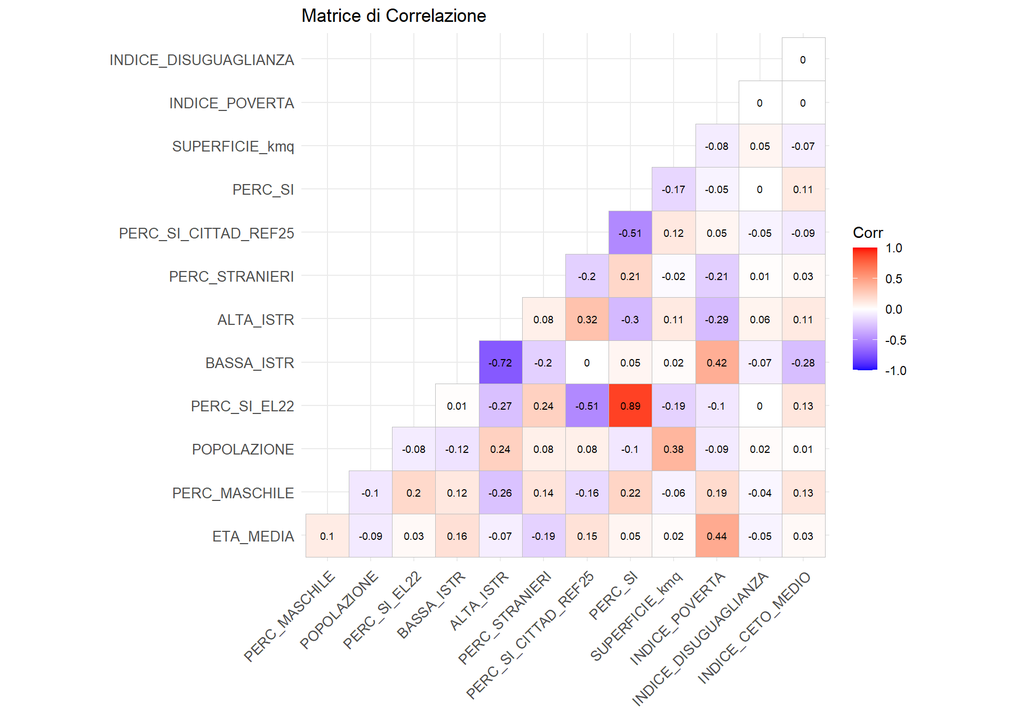

Matrice di Correlazione delle variabili indipendenti rispetto al target

```r
x <- f11[, -c(1, 2, 12, 13, 14)] # Rimozione features

ggcorrplot(cor(x[, -c(9,15,16)], use = "pairwise.complete.obs"),
           method = "square",
           type = "lower",
           lab = TRUE,
           lab_size = 2.5,
           tl.cex = 10,
           tl.srt = 45,
           colors = c("blue", "white", "red"),
           title = "Matrice di Correlazione",
           ggtheme = theme_minimal())
```

> **Osservazione**: Il predittore con la correlazione più alta rispetto alla variabile risposta quantitativa (`PERC_SI`) è `PERC_SI_EL22`, ovvero il comportamento di voto storico. Il messaggio è chiaro: i comuni che nel 2022 hanno votato partiti favorevoli al SÌ tendono a riproporre lo stesso orientamento nel 2026. Si tratta di inerzia elettorale, un fenomeno ben documentato in letteratura e che qui si manifesta con una solidità notevole. Le variabili demografiche, pur correlate tra loro, mostrano segnali più deboli verso il target il che anticipa già che il loro contributo predittivo sarà reale ma secondario rispetto alla storia politica del territorio.

## 2.3 Analisi dei Dati Mancanti

La copertura elettorale non è garantita per tutti i comuni: un partito che nel 2022 non era presente in una data area, o che non aveva preso una posizione esplicita sul quesito referendario, genera automaticamente un valore mancante in `PERC_SI_EL22`. È quindi un problema strutturale, non un difetto di raccolta dati.

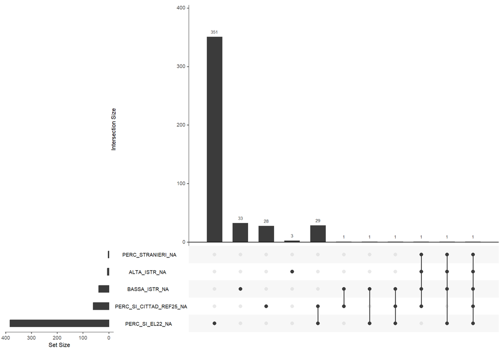

Intersezioni dei dati mancanti

```r
upset(as_shadow_upset(x))
```

> **Tipologia di mancanza**: L’UpSet plot e la mappa spaziale mostrano che i missing non sono distribuiti a caso tra i comuni (il che esclude l’ipotesi MCAR). Sono invece concentrati in Trentino-Alto Adige e Valle d’Aosta regioni dove la struttura dell’offerta politica è storicamente diversa da quella nazionale. Dal punto di vista statistico, questa è una situazione di **MAR (Missing At Random)**: la probabilità che un dato manchi è interamente spiegabile dalla posizione geografica del comune, una variabile presente nel dataset. Questa distinzione non è solo accademica: se i missing fossero MCAR potremmo semplicemente ignorarli; essendo MAR, ignorarli significherebbe introdurre un sistematico bias geografico nelle analisi successive.

### Localizzazione Spaziale dei Missing Value

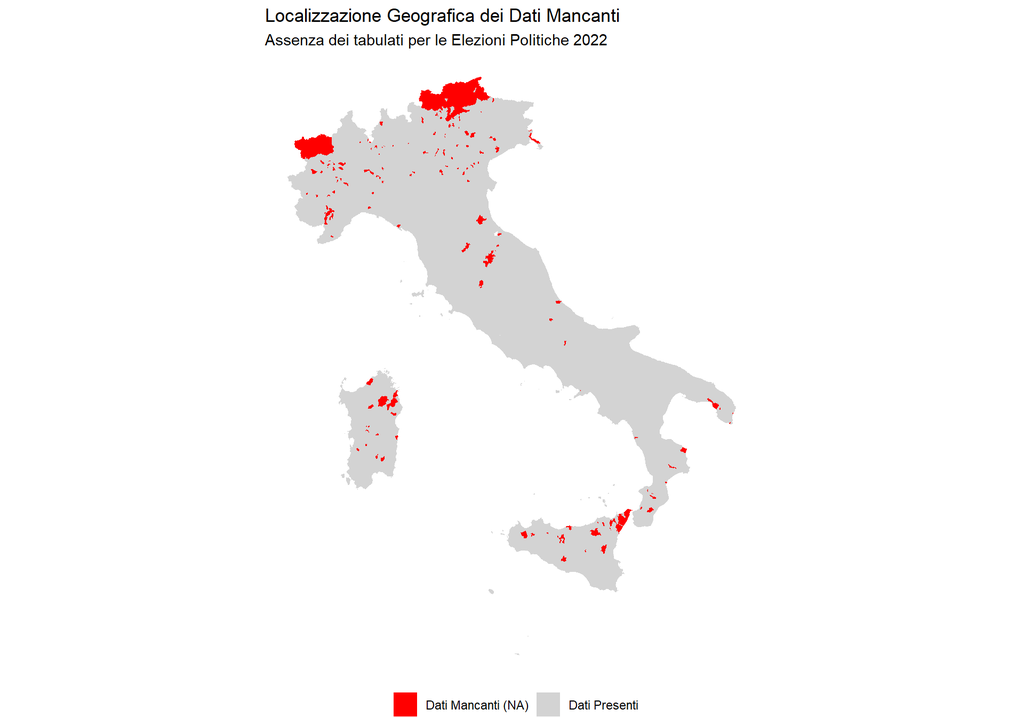

```r
mappa_comuni <- st_read("Com01012026_WGS84.shp", quiet = TRUE)

mappa_comuni2 <- mappa_comuni %>% mutate(Nome_Match = str_to_upper(str_trim(COMUNE)))
f11.2 <- f11 %>% mutate(Nome_Match = str_to_upper(str_trim(COMUNE)))

mappa_dati <- left_join(mappa_comuni2, f11.2, by = "Nome_Match")
mappa_controllo_na <- mappa_dati %>%
  mutate(Stato_Dato = ifelse(is.na(PERC_SI_EL22), "NA", "Presente"))

library(ggplot2)

ggplot(mappa_controllo_na) +
  geom_sf(aes(fill = Stato_Dato), color = NA) +
  scale_fill_manual(
    values = c("NA" = "red", "Presente" = "lightgray"),
    labels = c("Dati Mancanti (NA)", "Dati Presenti")
  ) +
  theme_void() +
  labs(
    title = "Localizzazione Geografica dei Dati Mancanti",
    subtitle = "Assenza dei tabulati per le Elezioni Politiche 2022",
    fill = ""
  ) +
  theme(legend.position = "bottom")
```

### Distribuzione condizionata dei Missing Data

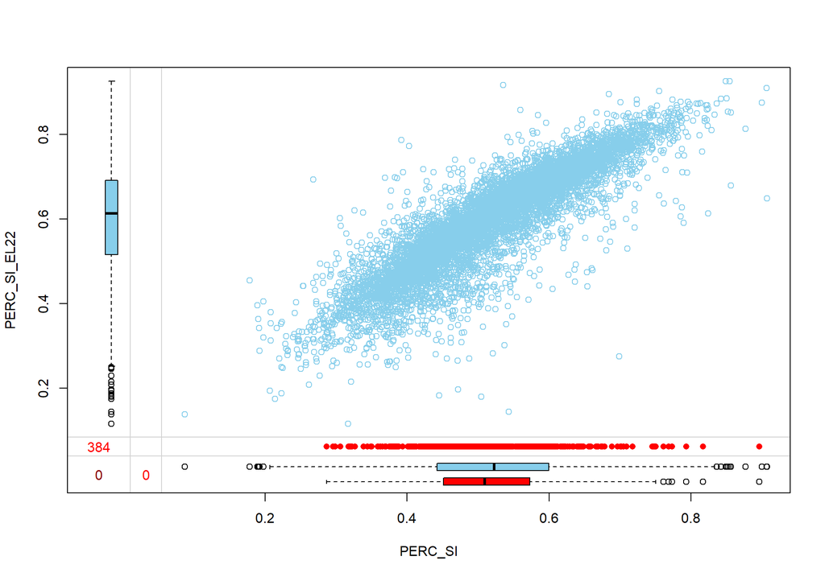

Marginplot: Relazione tra il Target Referendario e gli NA Storici

```r
marginplot(f11[c(15,6)])
```

```r
pMiss <- function(x){sum(is.na(x))/length(x)*100}
apply(f11, 2, pMiss)
```

```
##                COMUNE         CODICE_COMUNE             ETA_MEDIA
##            0.00000000            0.00000000            0.00000000
##         PERC_MASCHILE           POPOLAZIONE          PERC_SI_EL22
##            0.00000000            0.00000000            4.86383787
##            BASSA_ISTR             ALTA_ISTR        PERC_STRANIERI
##            0.49398353            0.07599747            0.03799873
##  PERC_SI_CITTAD_REF25         POSIZIONE_GEO           NUM_VOTI_SI
##            0.77264091            0.00000000            0.00000000
##           NUM_VOTI_NO                 SI_NO               PERC_SI
##            0.00000000            0.00000000            0.00000000
##        SUPERFICIE_kmq        INDICE_POVERTA INDICE_DISUGUAGLIANZA
##            0.00000000            0.00000000            0.00000000
##     INDICE_CETO_MEDIO          DENSITA_Xkmq    FASCIA_POPOLAZIONE
##            0.00000000            0.00000000            0.00000000
```

## 2.4 Dinamiche di Voto e Spostamenti Demografici

Il quadrante politico che segue disperde i comuni mettendo in relazione il voto storico del 2022 con quello referendario del 2026, con dimensione proporzionale alla popolazione.

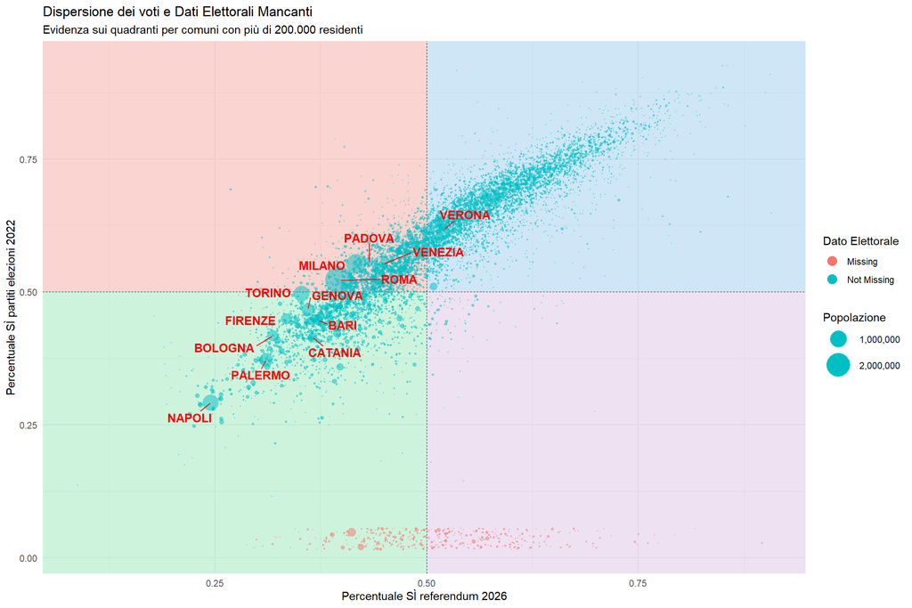

```r
ggplot(f11, aes(x = PERC_SI, y = PERC_SI_EL22)) +
  annotate("rect", xmin = -Inf, xmax = 0.5, ymin = -Inf, ymax = 0.5, fill = "#82E0AA", alpha = 0.4) +
  annotate("rect", xmin = 0.5, xmax = Inf, ymin = -Inf, ymax = 0.5, fill = "#D2B4DE", alpha = 0.4) +
  annotate("rect", xmin = -Inf, xmax = 0.5, ymin = 0.5, ymax = Inf, fill = "#F1948A", alpha = 0.4) +
  annotate("rect", xmin = 0.5, xmax = Inf, ymin = 0.5, ymax = Inf, fill = "#85C1E9", alpha = 0.4) +
  geom_vline(xintercept = 0.5, color = "black", linewidth = 0.3, linetype = "dashed") +
  geom_hline(yintercept = 0.5, color = "black", linewidth = 0.3, linetype = "dashed") +
  geom_miss_point(aes(size = POPOLAZIONE), alpha = 0.5) +
  geom_text_repel(
    data = subset(f11, POPOLAZIONE > 200000),
    aes(label = COMUNE),
    size = 4.0, colour = "red", fontface = "bold", max.overlaps = Inf, box.padding = 0.6
  ) +
  scale_size_area(max_size = 12, labels = scales::comma) +
  guides(
    size = guide_legend(override.aes = list(color = "#00BFC4", alpha = 0.5)),
    color = guide_legend(override.aes = list(size = 4))
  ) +
  theme_minimal() +
  labs(
    title = "Dispersione dei voti e Dati Elettorali Mancanti",
    subtitle = "Evidenza sui quadranti per comuni con più di 200.000 residenti",
    x = "Percentuale SÌ referendum 2026",
    y = "Percentuale SÌ partiti elezioni 2022",
    size = "Popolazione",
    color = "Dato Elettorale"
  ) +
  theme(legend.background = element_rect(fill = "white", color = NA, alpha = 0.8))
```

### Sintesi: cosa racconta il quadrante politico

La nuvola di punti si dispone prevalentemente lungo la diagonale, a confermare che i comuni del 2026 votano in buona misura come nel 2022 con una differenza importante: la nuvola è traslata verso sinistra rispetto alla bisettrice. Significa che, a parità di orientamento storico, il referendum ha raccolto meno SÌ di quanti i partiti ne avessero “promessi”. Il NO ha sovraperformato rispetto alle aspettative implicite del voto politico.

## 2.5 Modellazione Diagnostica: Cattura degli Outlier

Una regressione lineare su `PERC_SI` serve qui come strumento diagnostico, non predittivo. Il modello lineare ammette valori fuori dall’intervallo [0,1], ma quello che ci interessa non è la previsione in sé, bensì i residui: i comuni che si comportano in modo sistematicamente diverso da come le loro covariate lascerebbero attendersi.

```r
f11_completo <- f11 %>% drop_na()

modello <- lm(PERC_SI ~ PERC_MASCHILE + PERC_SI_EL22 + SUPERFICIE_kmq + INDICE_DISUGUAGLIANZA +
              PERC_SI_CITTAD_REF25 + POSIZIONE_GEO + DENSITA_Xkmq + FASCIA_POPOLAZIONE,
              data = f11_completo[, -c(1, 2, 12, 13, 14)],
              na.action = na.exclude)
summary(modello)
```

### Anomalia Statistica (Residui Studentizzati)

I residui studentizzati identificano i comuni che si discostano dalla norma regressiva. Si fissa una soglia cromatica a |3| e una soglia di etichettatura a |5| quest’ultima per distinguere le anomalie estreme.

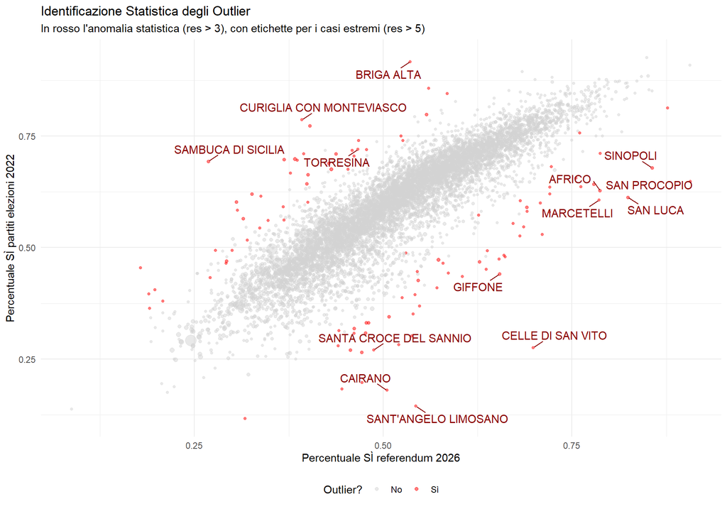

```r
f11_outlier <- f11_completo %>%
  mutate(
    Residui = rstudent(modello),
    E_Outlier = ifelse(abs(Residui) > 3, "Sì", "No")
  )

ggplot(f11_outlier, aes(x = PERC_SI, y = PERC_SI_EL22)) +
  geom_point(aes(color = E_Outlier, size = POPOLAZIONE), alpha = 0.5) +
  scale_color_manual(values = c("No" = "lightgrey", "Sì" = "red")) +
  geom_text_repel(
    data = subset(f11_outlier, abs(Residui) > 5),
    aes(label = COMUNE),
    size = 4, color = "darkred", box.padding = 0.5, max.overlaps = Inf
  ) +
  scale_size_continuous(range = c(1, 8), guide = "none") +
  theme_minimal() +
  labs(
    title = "Identificazione Statistica degli Outlier",
    subtitle = "In rosso l'anomalia statistica (res > 3), con etichette per i casi estremi (res > 5)",
    x = "Percentuale SÌ referendum 2026",
    y = "Percentuale SÌ partiti elezioni 2022",
    color = "Outlier?"
  ) +
  theme(legend.position = "bottom")
```

> **L’effetto micro-comune**: I punti rossi estremi hanno tutti dimensioni molto piccole nel grafico (e diametri minuscoli in termini di popolazione). È un fenomeno noto: nei comuni con poche centinaia di elettori, uno spostamento di una manciata di voti produce variazioni percentuali enormi. Briga Alta, Curiglia e gli altri comuni alpini etichettati sono casi dove probabilmente dinamiche locali molto specifiche un sindaco, un’ondata demografica, un’emigrazione stagionale hanno completamente sovvertito il quadro atteso dalle statistiche. All’opposto, comuni come Africo e Celle di San Vito mostrano tassi di SÌ alti rispetto a quanto ci si aspettava.

### Comuni Influenti (Distanza di Cook)

L’outlier e il punto di leva sono concetti distinti. Un comune può deviare fortemente dalla norma statistica (outlier) senza influenzare i coefficienti del modello, oppure può avere covariate estreme (leva) e per questo attirare su di sé l’intera retta di regressione, anche votando “come previsto”.

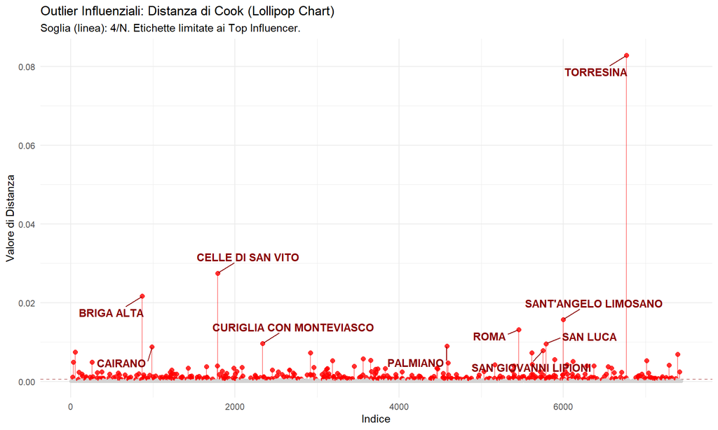

```r
f11_cook <- f11_outlier %>%
  mutate(Cooks_D = cooks.distance(modello), Indice = row_number())

soglia_cook <- 4 / nrow(f11_cook)
top_estremisti_cook <- f11_cook %>% arrange(desc(Cooks_D)) %>% head(10)

ggplot(f11_cook, aes(x = Indice, y = Cooks_D)) +
  geom_hline(yintercept = soglia_cook, color = "darkred", linetype = "dashed", alpha = 0.5) +
  geom_segment(aes(xend = Indice, yend = 0, color = Cooks_D > soglia_cook), alpha = 0.5) +
  geom_point(aes(color = Cooks_D > soglia_cook, size = Cooks_D > soglia_cook), alpha = 0.8) +
  scale_color_manual(values = c("FALSE" = "lightgray", "TRUE" = "red")) +
  scale_size_manual(values = c("FALSE" = 1.0, "TRUE" = 2.0)) +
  geom_text_repel(
    data = top_estremisti_cook,
    aes(label = COMUNE),
    size = 3.8, color = "darkred", fontface = "bold", box.padding = 0.8,
    min.segment.length = 0, max.overlaps = Inf
  ) +
  theme_minimal() +
  labs(
    title = "Outlier Influenziali: Distanza di Cook (Lollipop Chart)",
    subtitle = paste("Soglia (linea): 4/N. Etichette limitate ai Top Influencer."),
    x = "Indice", y = "Valore di Distanza"
  ) + theme(legend.position = "none")
```

## 2.6 MICE Imputation Data & Data Scaling

Per evitare il data leakage, il dataset viene diviso in training (75%) e test (25%) prima di qualsiasi imputazione. Il modello MICE viene stimato sul solo training set, poi applicato al test set tramite `mice.mids` (funzione che permette di applicare un modello di imputazione già calcolato a un nuovo dataset).

```r
x <- f11[, -c(1, 2, 12, 13, 15, 20, 21)]

set.seed(100)
id_TR <- sample(1:nrow(x), nrow(x)*0.75)

TRAINING.set <- x[id_TR, ]
TEST.set     <- x[-id_TR, ]

p <- dim(TRAINING.set)[2]
my_predictorMatrix <- 1 - diag(nrow = p, ncol = p)
my_predictorMatrix[, 10] <- 0

impTRAINING <- mice(TRAINING.set, method = "pmm", predictorMatrix = my_predictorMatrix,
                    seed = 100, m = 5, maxit = 10, printFlag = FALSE)

impTEST <- mice.mids(impTRAINING, newdata = TEST.set)

# ESTRAZIONE DAI MODELLI MICE

df_train_imputato <- complete(impTRAINING, 1)
df_test_imputato  <- complete(impTEST, 1)

# REINSERIMENTO DELLE VARIABILI TOLTE IN PRECEDENZA

colonne_tolte_TR <- f11[id_TR,  c(1,2,20,21)]
colonne_tolte_TE <- f11[-id_TR, c(1,2,20,21)]

df_train <- cbind(df_train_imputato, colonne_tolte_TR)
df_test  <- cbind(df_test_imputato, colonne_tolte_TE)

# AGGIUNTA VARIABILI TRASFORMATE
df_train$LOG_POPOLAZIONE <- log(df_train$POPOLAZIONE + 1)
df_test$LOG_POPOLAZIONE  <- log(df_test$POPOLAZIONE + 1)

df_train$LOG_DENSITA <- log(df_train$DENSITA_Xkmq + 1)
df_test$LOG_DENSITA  <- log(df_test$DENSITA_Xkmq + 1)

df_train$LOG_SUPERFICIE <- log(df_train$SUPERFICIE_kmq + 1)
df_test$LOG_SUPERFICIE  <- log(df_test$SUPERFICIE_kmq + 1)

# NORMALIZZAZIONE (MIN-MAX: Raggio 0 - 1)

col_numeriche <- names(df_train)[sapply(df_train, is.numeric)]

da_non_scalare <- c("CODICE_COMUNE")
col_da_scalare <- setdiff(col_numeriche, da_non_scalare)

minimi_TRAIN  <- apply(df_train[, col_da_scalare], 2, min, na.rm = TRUE)
massimi_TRAIN <- apply(df_train[, col_da_scalare], 2, max, na.rm = TRUE)

TRAIN_FINALE <- df_train
TEST_FINALE  <- df_test

for(col in col_da_scalare) {

  TRAIN_FINALE[[col]] <- (df_train[[col]] - minimi_TRAIN[col]) /
    (massimi_TRAIN[col] - minimi_TRAIN[col])

  # MINIMO E MASSIMO IMPARATI DAL TRAIN
  TEST_FINALE[[col]]  <- (df_test[[col]]  - minimi_TRAIN[col]) /
    (massimi_TRAIN[col] - minimi_TRAIN[col])
}

TRAIN_FINALE <- TRAIN_FINALE %>% select(COMUNE, CODICE_COMUNE, everything())
TEST_FINALE <- TEST_FINALE %>% select(COMUNE, CODICE_COMUNE, everything())

write.csv(TRAIN_FINALE, file = "TRAINING.SET.csv", row.names = FALSE)
write.csv(TEST_FINALE, file = "TEST.SET.csv", row.names = FALSE)
```

> **Giustificazione Metodologica sulla Data Scaling**

> Per garantire omogeneità dimensionale ai successivi algoritmi di Machine Learning, l’intero blocco di predittori numerici è stato scalato all’interno di un raggio standard $[0, 1]$ tramite **Min-Max Scaling**. Contrariamente all’impiego della Standardizzazione, si è optato per il Min-Max per: mantenere geometricamente inalterate le proporzioni di dispersione originali e non forzare la varianza ad assumere un profilo inesistente nel mondo reale. Parallelamente, per attenuare l’eteroschedasticità di variabili territoriali soggette a divari strutturali (come la `Densità Abitativa` o la `Popolazione`), prima dello scaling sono state calcolate trasformazioni Logaritmiche ($log(X+1)$). Infine, **per evitare Data Leakage**, la mappatura dei pesi e dei limiti (i vettori dei `MIN` e `MAX`) è stata “imparata” esclusivamente sul set di Training, per poi essere proiettata e applicata sui vettori del set di Test.

I grafici diagnostici che seguono vengono generati sul test set. La logica è quella di valutare la capacità di generalizzazione del modello di imputazione su dati che non ha mai visto in fase di stima esattamente come si farebbe con qualsiasi altro modello predittivo.

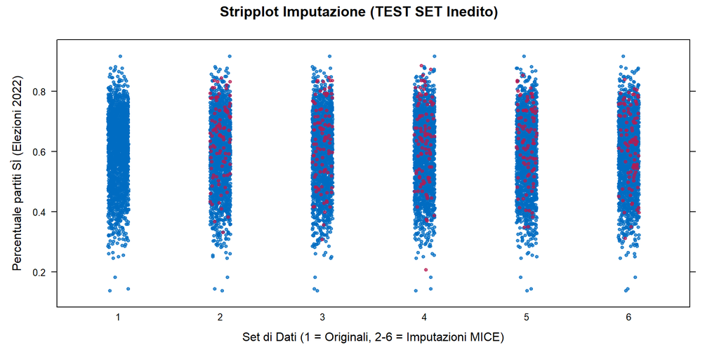

```r
stripplot(impTEST, PERC_SI_EL22 ~ .imp,
          pch = 20,
          ylab = "Percentuale partiti SÌ (Elezioni 2022)",
          xlab = "Set di Dati (1 = Originali, 2-6 = Imputazioni MICE)",
          main = "Stripplot Imputazione (TEST SET Inedito)")
```

> **Diagnostica Stripplot**: I valori imputati nei set 2-6 ricadono all’interno del range empirico dei dati originali (set 1), senza sfondare i limiti superiori o inferiori della distribuzione. L’imputazione non sta inventando valori improbabili: si comporta come un buon interpolatore che conosce il contesto geografico dei comuni mancanti.

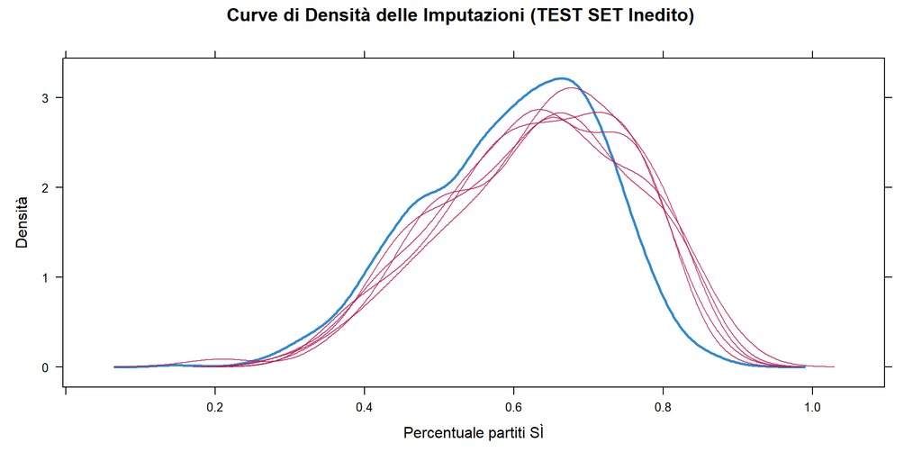

```r
densityplot(impTEST, ~ PERC_SI_EL22,
            main = "Curve di Densità delle Imputazioni (TEST SET Inedito)",
            ylab = "Densità", xlab = "Percentuale partiti SÌ")
```

> **Diagnostica Densityplot**: Le cinque curve rosse (imputazioni PMM) si sovrappongono bene alla curva originale blu. Si nota un lieve spostamento verso destra rispetto ai dati osservati, ovvero le imputazioni sono mediamente più favorevoli al SÌ, coerente col fatto che i comuni con dato mancante sono prevalentemente settentrionali, storicamente più orientati verso il SÌ.

> **Nota Metodologica sull’Estrazione Singola (m=1)**: Osservando sia lo *Stripplot* che il *Densityplot*, si evince come le 5 curve (e nuvole di punti) imputate risultino sovrapponibili fra loro. Questa stretta convergenza visiva dimostra empiricamente che la “Varianza Between-Imputations” (ovvero l’incertezza del modello MICE tra un’iterazione e l’altra) è prossima allo zero. Poiché l’algoritmo PMM si è rivelato coerente e stabile nel ricostruire i dati mancanti in quel circoscritto 5% geografico, si deduce che lavorare con l’imputazione numero 1, la 3 o la 5 avrebbe generato matrici statisticamente indistinguibili. Optare per una singola estrazione su base PMM ci ha dunque consentito di impiegare MICE come stimatore predittivo.

# 3. Modelli Parametrici

## 3.1 Preparazione dei Dati

La funzione `calc_metrics` calcola le metriche di performance standard (Accuracy, Sensitivity, Specificity, Precision) a partire da una matrice di confusione 2×2. Il SÌ è convenuto come outcome positivo in tutti i calcoli.

```r
calc_metrics <- function(cm) {
  tp <- cm["si", "si"]
  tn <- cm["no", "no"]
  fp <- cm["si", "no"]
  fn <- cm["no", "si"]

  acc  <- (tp + tn) / sum(cm)
  sens <- tp / (tp + fn)
  spec <- tn / (tn + fp)
  prec <- tp / (tp + fp)

  data.frame(
    Accuracy    = round(acc,  3),
    Sensitivity = round(sens, 3),
    Specificity = round(spec, 3),
    Precision   = round(prec, 3)
  )
}
```

### 3.1.1 Verifica del Bilanciamento delle Classi

```r
cat("--- TRAINING SET ---\n")
```

```
## --- TRAINING SET ---
```

```r
round(prop.table(table(dataset_train$SI_NO)) * 100, 1)
```

```
##
##   no   si
## 42.2 57.8
```

```r
cat("\n--- TEST SET ---\n")
```

```
##
## --- TEST SET ---
```

```r
round(prop.table(table(dataset_test$SI_NO)) * 100, 1)
```

```
##
## no si
## 43 57
```

> **Verifica delle Proporzioni e Affidabilità dell’Accuracy**

> Come si evince dalle percentuali di classe appena calcolate, il partizionamento dei dati ha generato una suddivisione statisticamente solida in entrambi i set (circa 42-43% per il NO e 57-58% per il SÌ). In primo luogo, questa coerenza percentuale conferma la perfetta riuscita dello split, assicurando che ogni modello venga validato su un campione fedele alla realtà su cui è stato addestrato. In secondo luogo, le due classi si presentano **relativamente ben bilanciate**. Questa evidenza empirica è vitale poiché risolve il problema della mancanza di una baseline chiara (*Class Imbalance Problem*).

## 3.2 Modello di Regressione Logistica

Il punto di partenza è una regressione logistica con tutte le covariate disponibili. Il modello completo serve da benchmark: qualsiasi modello penalizzato che seguirà dovrà giustificare la propria parsimonia con performance almeno comparabili.

```r
m1 <- glm(SI_NO ~ ., family = binomial, data = data)

pred_prob_train  <- predict(m1, newdata = data, type = "response")
pred_class_train <- ifelse(pred_prob_train > 0.5, "si", "no")

cm_train_log <- table(predicted = pred_class_train, actual = data$SI_NO)
print(cm_train_log)
```

```
##          actual
## predicted   no   si
##        no 1709  576
##        si  790 2846
```

```r
pred_prob_glm  <- predict(m1, newdata = test, type = "response")
pred_class_glm <- ifelse(pred_prob_glm > 0.5, "si", "no")

cm_test_log <- table(predicted = pred_class_glm, actual = test$SI_NO)
print(cm_test_log)
```

```
##          actual
## predicted  no  si
##        no 576 201
##        si 272 925
```

```r
metrics_log <- calc_metrics(cm_test_log)
```

**Commento:** Sul test set la logistica completa raggiunge un’accuracy di 0.76, con sensitivity 0.821 e specificity 0.679. Il gap contenuto rispetto al training esclude un overfitting marcato. Va però tenuto a mente che l’inclusione di tutte le covariate in presenza di multicollinearità (gli indici PCA sono ortogonali, ma le variabili di istruzione si sovrappongono) rende i singoli coefficienti instabili: il modello classifica bene ma non è detto che i pesi individuali siano interpretabili con fiducia.

## 3.3 Modello LASSO Logistico

### 3.3.1 Formulazione del problema

La regressione logistica stima i coefficienti massimizzando la log-verosimiglianza $\ell(\boldsymbol{\beta})$. Quando le covariate sono molte o correlate, questo approccio produce stime ad alta varianza. Il **LASSO** (Tibshirani 1996) affronta il problema penalizzando la norma $\ell_1$ del vettore dei coefficienti:

$$\hat{\boldsymbol{\beta}}_{\text{LASSO}}
= \arg\max_{\boldsymbol{\beta}} \left[ \ell(\boldsymbol{\beta}) -
\lambda \sum_{j=1}^{p} |\beta_j| \right]$$

Il parametro $\lambda \geq 0$ controlla la forza della penalizzazione. La proprietà distintiva del LASSO rispetto alla penalizzazione Ridge ($\ell_2$) è che la norma $\ell_1$ produce soluzioni sparse: al crescere di $\lambda$, un numero crescente di coefficienti viene portato esattamente a zero, realizzando di fatto una selezione automatica delle variabili.

### 3.3.2 Stima e selezione di $\lambda$

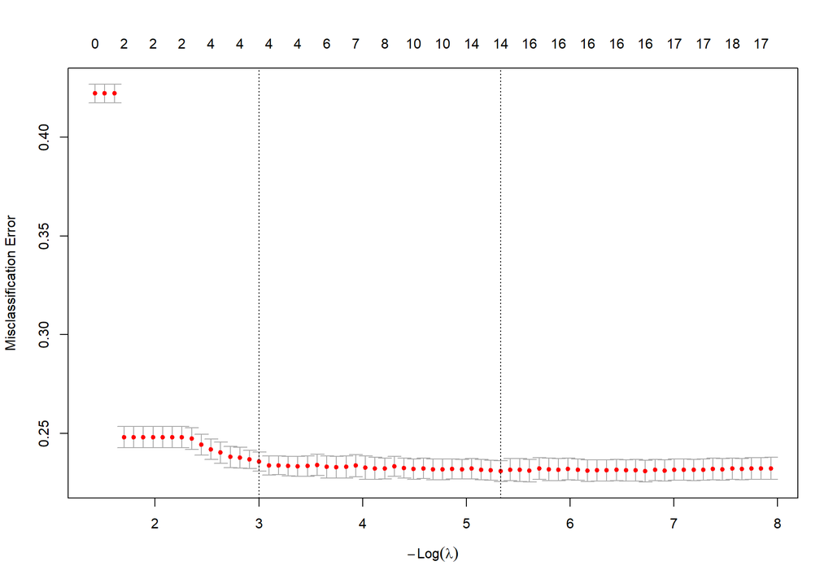

```r
library(glmnet)
library(pROC)

x_train <- model.matrix(SI_NO ~ ., data)[,-1]
y_train  <- data$SI_NO

x_test <- model.matrix(SI_NO ~ ., test)[,-1]
y_test <- test$SI_NO

cv_lasso <- cv.glmnet(
  x            = x_train,
  y            = y_train,
  family       = "binomial",
  nfolds       = 10,
  type.measure = "class"
)

plot(cv_lasso)
```

Il grafico mostra l’errore di classificazione in cross-validation al variare di $\log(\lambda)$. Si considerano due punti di riferimento canonici:

- **`lambda.min`**: minimizza l’errore in CV modello più ricco ma potenzialmente instabile.
- **`lambda.1se`**: il valore più restrittivo la cui performance in CV non si discosta da `lambda.min` di più di una deviazione standard modello più parsimonioso e con migliore generalizzazione attesa.

Da questo punto si adotta **`lambda.1se`** come valore di riferimento.

```r
pred_class_lasso_train <- predict(cv_lasso, newx = x_train, s = "lambda.1se", type = "class")
table(predicted = pred_class_lasso_train, actual = y_train)
```

```
##          actual
## predicted   no   si
##        no 1605  500
##        si  894 2922
```

```r
pred_class_test <- predict(cv_lasso, newx = x_test, s = "lambda.1se", type = "class")
cm_test_lasso   <- table(predicted = pred_class_test, actual = y_test)
print(cm_test_lasso)
```

```
##          actual
## predicted  no  si
##        no 536 168
##        si 312 958
```

```r
metrics_lasso <- calc_metrics(cm_test_lasso)

pred_prob_lasso <- as.vector(predict(cv_lasso, newx = x_test, s = "lambda.1se", type = "response"))
roc_lasso       <- roc(response = y_test, predictor = pred_prob_lasso, quiet = TRUE)
```

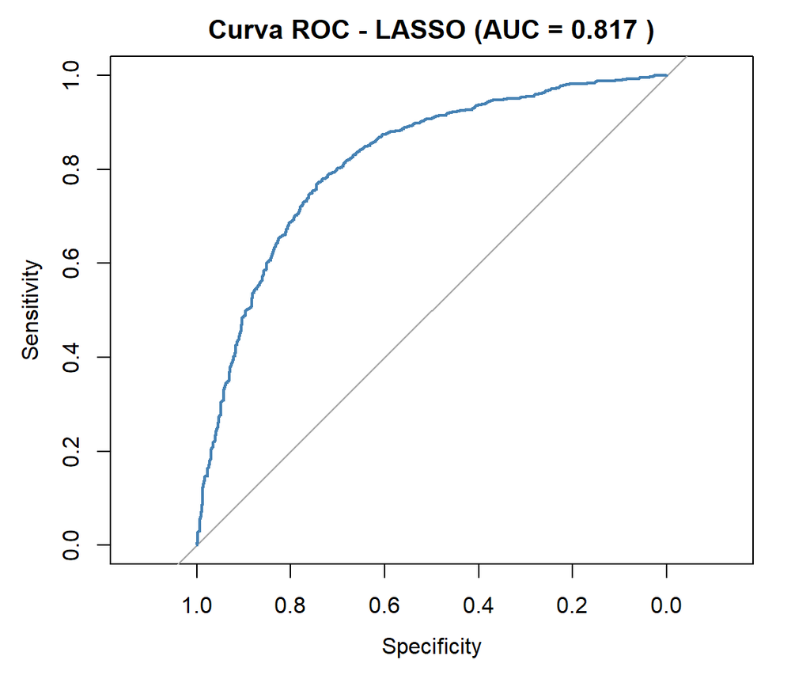

**Commento:** Il LASSO con `lambda.1se` ottiene sul test set un’accuracy di 0.757 e un AUC di 0.817 sostanzialmente allineato alla logistica completa, ma con un numero molto inferiore di predittori attivi. È il tipico trade-off bias-varianza in azione: la penalizzazione introduce un piccolo bias nei coefficienti sopravvissuti, ma la riduzione della varianza compensa ampiamente in termini di stabilità predittiva out-of-sample.

## 3.4 Relaxed LASSO

### 3.4.1 Motivazione e formulazione

Il LASSO ha un difetto strutturale: la penalità $\ell_1$, oltre a selezionare le variabili, *comprime* i coefficienti dei predittori che sopravvivono alla selezione. Questi predittori vengono stimati con un bias verso zero anche quando dovrebbero essere stimati liberamente. Se l’obiettivo è l’interpretazione dei coefficienti o la massimizzazione delle performance predittive questo bias di shrinkage è indesiderato.

Il **Relaxed LASSO** (Meinshausen 2007) risolve il problema in due fasi. Sia $\hat{S}(\lambda)$ il sottoinsieme di predittori non nulli alla soluzione LASSO con parametro $\lambda$. Il modello rilassato risolve:

$$\hat{\boldsymbol{\beta}}_{\text{relax}}
= \arg\max_{\boldsymbol{\beta}} \left[ \ell(\boldsymbol{\beta}) - \gamma
\lambda \sum_{j \in \hat{S}(\lambda)} |\beta_j| \right]$$

dove $\gamma \in [0,1]$ controlla il grado di rilassamento:

- $\gamma = 1$: nessun rilassamento, equivale al LASSO standard.
- $\gamma = 0$: penalità completamente rimossa sui predittori selezionati — equivalente a stimare una logistica pura sul sottoinsieme $\hat{S}(\lambda)$ (Post-LASSO).
- $0 < \gamma < 1$: compromesso intermedio che riduce il bias mantenendo una regolarizzazione residua.

In `glmnet`, `relax = TRUE` esplora automaticamente la griglia di combinazioni $(\lambda, \gamma)$ tramite cross-validation.

### 3.4.2 Stima

```r
cv_lasso_relaxed <- cv.glmnet(
  x            = x_train,
  y            = y_train,
  family       = "binomial",
  nfolds       = 10,
  relax        = TRUE,
  type.measure = "class"
)

gamma_opt <- cv_lasso_relaxed$relaxed$gamma.1se

pred_class_test_relax <- predict(cv_lasso_relaxed,
                                  newx  = x_test,
                                  s     = "lambda.1se",
                                  gamma = gamma_opt,
                                  type  = "class")

cm_test_relax <- table(predicted = pred_class_test_relax, actual = y_test)
print(cm_test_relax)
```

```
##          actual
## predicted  no  si
##        no 550 174
##        si 298 952
```

```r
metrics_relax <- calc_metrics(cm_test_relax)
```

**Commento:** Il valore ottimale di $\gamma$ selezionato dalla CV è 0.5. Un $\gamma < 1$ conferma che il rilassamento parziale è vantaggioso: la cross-validation premia modelli in cui i coefficienti sui predittori selezionati vengono lasciati “respirare” rispetto alla soluzione LASSO pura. Se $\gamma = 0$, il Relaxed LASSO coincide matematicamente col Post-LASSO della sezione successiva.

## 3.5 Selezione delle Variabili con LASSO e Regressione Finale (Post-LASSO)

L’ultimo modello parametrico adotta una strategia in due passi: prima si usa il LASSO per identificare il sottoinsieme di predittori rilevanti, poi si ri-stima una logistica classica senza penalizzazione su quel sottoinsieme. Questo elimina completamente il bias di shrinkage dai coefficienti finali, rendendo valida l’inferenza su di essi.

```r
coef_lasso <- coef(cv_lasso, s = "lambda.1se")
coef_lasso
```

```
## 20 x 1 sparse Matrix of class "dgCMatrix"
##                           lambda.1se
## (Intercept)                1.0430016
## ETA_MEDIA                  .
## PERC_MASCHILE              .
## POPOLAZIONE                .
## BASSA_ISTR                 .
## ALTA_ISTR                 -1.8842823
## PERC_STRANIERI             .
## POSIZIONE_GEON             0.8558860
## POSIZIONE_GEOS            -1.0405062
## SUPERFICIE_kmq             .
## INDICE_POVERTA             .
## INDICE_DISUGUAGLIANZA      .
## INDICE_CETO_MEDIO          .
## DENSITA_Xkmq               .
## FASCIA_POPOLAZIONEMedio    .
## FASCIA_POPOLAZIONEMicro    .
## FASCIA_POPOLAZIONEPiccolo  .
## LOG_POPOLAZIONE           -0.8922716
## LOG_DENSITA                .
## LOG_SUPERFICIE             .
```

```r
m_post <- glm(SI_NO ~ ALTA_ISTR + POSIZIONE_GEO + LOG_POPOLAZIONE,
              family = binomial,
              data   = data)

pred_prob_post  <- predict(m_post, newdata = test, type = "response")
pred_class_post <- ifelse(pred_prob_post > 0.5, "si", "no")

cm_post <- table(predicted = pred_class_post, actual = test$SI_NO)
print(cm_post)
```

```
##          actual
## predicted  no  si
##        no 571 189
##        si 277 937
```

```r
metrics_post <- calc_metrics(cm_post)
```

**Commento:** Il LASSO seleziona solo 3 predittori su 19 disponibili: `ALTA_ISTR`, `POSIZIONE_GEO` e `LOG_POPOLAZIONE`. La scelta è interpretabile: istruzione terziaria, collocazione geografica Nord/Centro/Sud e dimensione del comune sono le tre dimensioni strutturali che, da sole, riescono a catturare la maggior parte della variabilità nell’esito referendario. Il fatto che il modello finale con soli 3 predittori raggiunga un’accuracy di 0.764, la più alta tra i quattro modelli parametrici non è un caso: la parsimonia forza il modello a concentrarsi sul segnale vero, scartando i predittori che aggiungono rumore.

## 3.6 Confronto Finale Tra i Modelli Parametrici

Metriche di performance sul Test Set

| Modello | Accuracy | Sensitivity | Specificity | Precision | AUC |
| --- | --- | --- | --- | --- | --- |
| Logistica Base | 0.760 | 0.821 | 0.679 | 0.773 | 0.822 |
| LASSO (1se) | 0.757 | 0.851 | 0.632 | 0.754 | 0.817 |
| Relaxed LASSO | 0.761 | 0.845 | 0.649 | 0.762 | 0.817 |
| LASSO + Logistica | 0.764 | 0.832 | 0.673 | 0.772 | 0.816 |

# 4. Modelli Non Parametrici ed Ensemble

## 4.1 Preparazione dei Dati

```r
library(tidyverse)

trn <- train %>%
  select(SI_NO, POSIZIONE_GEO, INDICE_POVERTA, INDICE_CETO_MEDIO, INDICE_DISUGUAGLIANZA, DENSITA_Xkmq,
         PERC_STRANIERI, BASSA_ISTR, ALTA_ISTR, ETA_MEDIA, PERC_MASCHILE)

tst_data <- test %>%
  select(POSIZIONE_GEO, INDICE_POVERTA, INDICE_CETO_MEDIO, INDICE_DISUGUAGLIANZA, DENSITA_Xkmq,
         PERC_STRANIERI, BASSA_ISTR, ALTA_ISTR, ETA_MEDIA, PERC_MASCHILE)
tst_lable <- test$SI_NO
```

*(La funzione `calc_metrics` è già disponibile nell’ambiente dall’inizializzazione precedente; il chunk seguente la ridefinisce in background per compatibilità.)*

## 4.2 Decision Tree

### 4.2.1 Albero decisionale con tutte le feature

Il **Decision Tree** costruisce una gerarchia di regole di classificazione tramite partizione ricorsiva binaria dello spazio delle feature. Come *white-box model*, permette di leggere direttamente quali variabili guidano la classificazione ad ogni nodo, rendendo l’output interpretabile anche senza un background statistico. Il criterio di splitting adottato è l’**Indice di Gini** ($Gini = \sum p_k(1-p_k)$), che misura l’impurità del nodo e viene utilizzato per la divisione verso sottogruppi più omogenei.

```r
library(tree)
albero <- tree(SI_NO ~ ., data = trn, split = "gini")
summary(albero)
```

```
##
## Classification tree:
## tree(formula = SI_NO ~ ., data = trn, split = "gini")
## Number of terminal nodes:  572
## Residual mean deviance:  0.5195 = 2779 / 5349
## Misclassification error rate: 0.128 = 758 / 5921
```

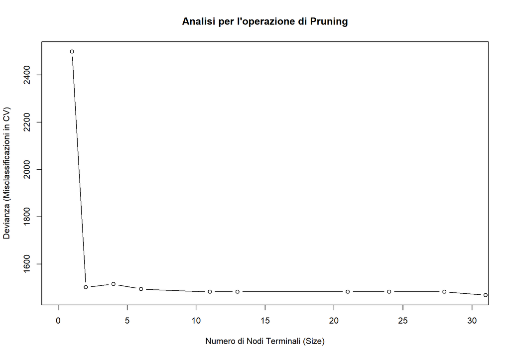

```r
cv_albero <- cv.tree(albero, FUN = prune.misclass)
plot(cv_albero$size, cv_albero$dev, type = "b", xlim = c(0,30),
     xlab = "Numero di Nodi Terminali (Size)",
     ylab = "Devianza (Misclassificazioni in CV)",
     main = "Analisi per l'operazione di Pruning")
```

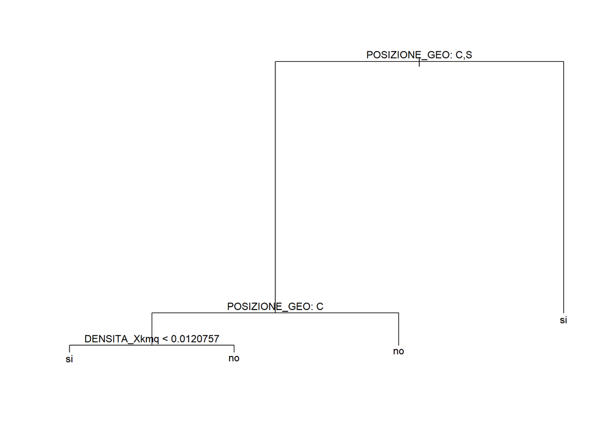

```r
prune.albero <- prune.misclass(albero, best = 4)
plot(prune.albero)
text(prune.albero, pretty = 0)
```

La prima divisione all’radice è sulla **posizione geografica**. L’albero non usa neanche una variabile demografica al primo livello: il territorio conta più di qualsiasi indicatore di istruzione, reddito o densità. Da una parte c’è il Nord, dall’altra il Centro-Sud, con una divisione netta che riflette differenze strutturali nei sistemi politici locali. Al secondo livello, per la componente centrale, entra la densità abitativa: i comuni densamente popolati del Centro si avvicinano al comportamento meridionale (NO), mentre quelli meno densi mostrano un orientamento più sfumato.

```r
previsione <- predict(prune.albero, tst_data, type = "class")
matrix_tree <- table(previsione, tst_lable)
calc_metrics(matrix_tree)
```

```
##   Accuracy Sensitivity Specificity Precision
## 1    0.764        0.85       0.651     0.764
```

### 4.2.2 Albero decisionale escludendo la posizione geografica

Rimosso il predittore geografico, si testa la capacità degli indicatori socio-demografici di lavorare in autonomia.

*(Nota: da questa sezione si utilizza `rpart`, che svolge in autonomia cross-validation e pruning.)*

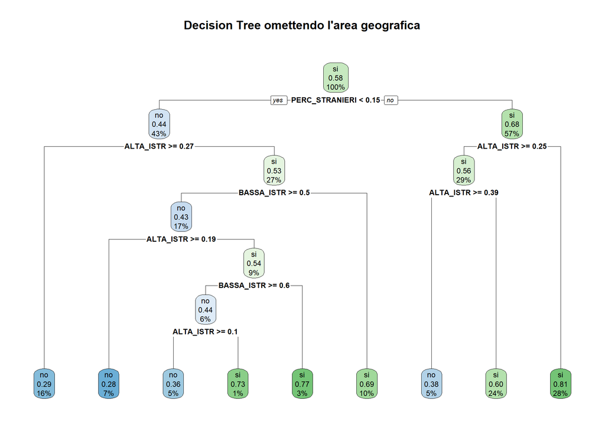

```r
library(rpart)
library(rpart.plot)

trn_no_pop <- train %>%
  select(SI_NO, INDICE_POVERTA, INDICE_CETO_MEDIO, INDICE_DISUGUAGLIANZA, DENSITA_Xkmq,
         PERC_STRANIERI, BASSA_ISTR, ALTA_ISTR, ETA_MEDIA, PERC_MASCHILE)

tst_data_no_pop <- test %>%
  select(INDICE_POVERTA, INDICE_CETO_MEDIO, INDICE_DISUGUAGLIANZA, DENSITA_Xkmq,
         PERC_STRANIERI, BASSA_ISTR, ALTA_ISTR, ETA_MEDIA, PERC_MASCHILE)
tst_lable_no_pop <- test$SI_NO

albero_no_pop <- rpart(SI_NO ~ ., data = trn_no_pop)
rpart.plot(albero_no_pop, main="Decision Tree omettendo l'area geografica")
```

> **Come leggere il grafico**: L’albero si legge dall’alto verso il basso. Si parte dal nodo radice e si scende seguendo le condizioni: il ramo *yes* va a sinistra quando la condizione è verificata, *no* va a destra. Ogni rettangolo contiene tre informazioni. La **classe predetta** (*sì*/*no*), la **proporzione** di casi che appartengono a quella classe (più è vicina a 1, più la predizione è netta), e la **percentuale** di osservazioni totali che arriva in quel nodo. Il colore segnala la direzione e la certezza della predizione: il verde indica *sì*, il blu indica *no*, e l’intensità cresce al crescere della certezza. I toni intermedi corrispondono a nodi ancora incerti.

```r
previsione_no_pop <- predict(albero_no_pop, tst_data_no_pop, type = "class")
matrix_no_pop <- table(previsione_no_pop, tst_lable_no_pop)
calc_metrics(matrix_no_pop)
```

```
##   Accuracy Sensitivity Specificity Precision
## 1     0.68       0.777       0.551     0.697
```

### 4.2.3 Albero decisionale con Covariate Politiche Storiche

Si reintroducono ora l’orientamento politico del 2022 (`PERC_SI_EL22`) e il risultato del Referendum Cittadinanza 2025 (`PERC_SI_CITTAD_REF25`).

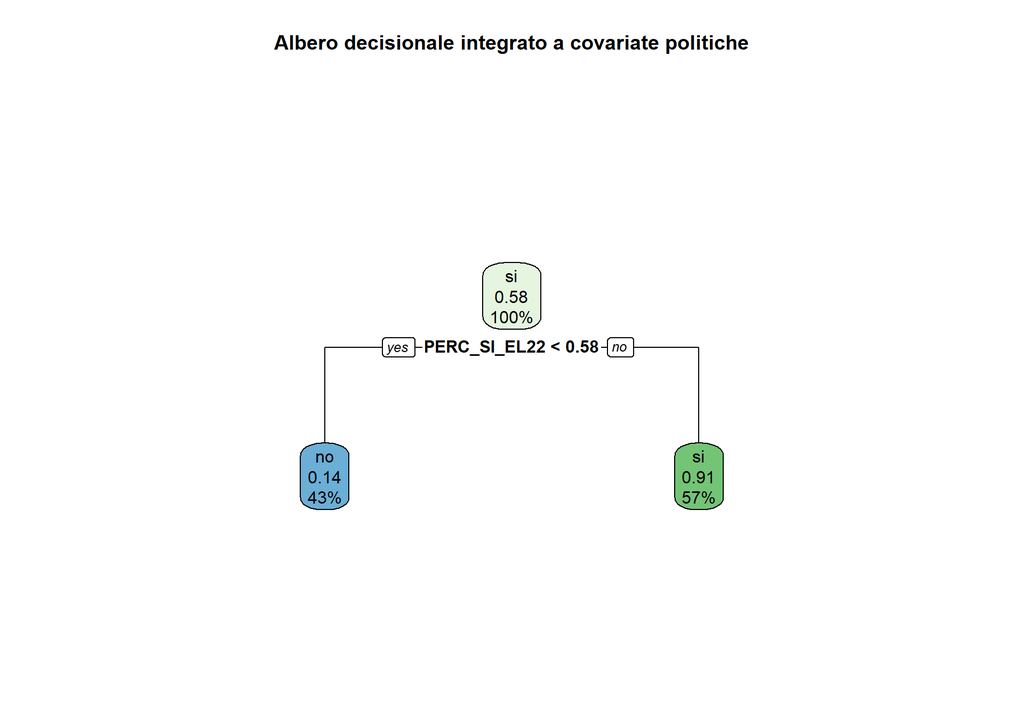

```r
trn_pol <- train %>%
  select(SI_NO, PERC_SI_EL22, PERC_SI_CITTAD_REF25, POSIZIONE_GEO, INDICE_POVERTA, INDICE_CETO_MEDIO,
         INDICE_DISUGUAGLIANZA, DENSITA_Xkmq, PERC_STRANIERI, BASSA_ISTR, ALTA_ISTR, ETA_MEDIA, PERC_MASCHILE)

tst_data_pol <- test %>%
  select(POSIZIONE_GEO, PERC_SI_EL22, PERC_SI_CITTAD_REF25, INDICE_POVERTA, INDICE_CETO_MEDIO,
         INDICE_DISUGUAGLIANZA, DENSITA_Xkmq, PERC_STRANIERI, BASSA_ISTR, ALTA_ISTR, ETA_MEDIA, PERC_MASCHILE)
tst_lable_pol <- test$SI_NO

albero_pol <- rpart(SI_NO ~ ., data = trn_pol)
rpart.plot(albero_pol, main="Albero decisionale integrato a covariate politiche")
```

```r
previsione_pol <- predict(albero_pol, tst_data_pol, type = "class")
matrix_pol <- table(previsione_pol, tst_lable_pol)
calc_metrics(matrix_pol)
```

```
##   Accuracy Sensitivity Specificity Precision
## 1    0.876       0.893       0.855     0.891
```

L’orientamento storico `PERC_SI_EL22` assorbe quasi tutto il peso predittivo: l’albero si riduce essenzialmente a una singola regola binaria “il comune avrebbe votato SÌ nel 2022?” e quasi tutto il resto scompare. Il risultato è coerente con quanto già emerso dalla matrice di correlazione e dal quadrante politico: il referendum 2026 è in larga misura un’eco del voto politico pregresso. Le variabili demografiche non aggiungono molto, una volta noto l’orientamento elettorale di partenza.

## 4.3 Random Forest

Il **Random Forest** è un algoritmo di Ensemble Learning che costruisce una molteplicità di alberi decisionali (`ntree = 500`) e li fa votare collettivamente sulla classificazione. La forza dell’approccio deriva da due meccanismi di stocasticità introdotti in fase di addestramento:

1. **Bagging** (Bootstrap Aggregating): ogni albero viene addestrato su un campione estratto con reimmissione dal dataset originale. Questo garantisce che i 500 alberi siano tra loro diversificati.
2. **Feature Subsampling**: ad ogni divisione di un nodo, si valutano solo $\sqrt{p}$ predittori scelti casualmente, impedendo a qualsiasi variabile dominante di monopolizzare la struttura di tutti gli alberi.

Il meccanismo combinato sopprime fortemente l’overfitting rispetto al singolo albero, al costo però dell’interpretabilità: non esiste un diagramma leggibile come quello dell’albero potato.Il Random Forest è un modello difficile da interpretare, una sorta di “scatola nera” che però riesce a classificare bene. La sezione XAI che segue serve proprio a rendere più chiaro come funziona.

```r
library(randomForest)

p <- ncol(trn) - 1
mtry_default <- floor(sqrt(p))

randomf <- randomForest(
  formula    = SI_NO ~ .,
  data       = trn,
  mtry       = mtry_default,
  ntree      = 500,
  importance = TRUE
)
randomf
```

```
##
## Call:
##  randomForest(formula = SI_NO ~ ., data = trn, mtry = mtry_default,      ntree = 500, importance = TRUE)
##                Type of random forest: classification
##                      Number of trees: 500
## No. of variables tried at each split: 3
##
##         OOB estimate of  error rate: 23.51%
## Confusion matrix:
##      no   si class.error
## no 1646  853   0.3413365
## si  539 2883   0.1575102
```

L’utilizzo di più alberi decisionali combinati tra loro, consente di ridurre il rischio di overfitting rispettoall’impiego di un singolo albero. Questo miglioramento delle prestazioni avviene però a scapito dell’interpretabilità: il modello risulta infatti più complesso e meno immediato da interpretare. Prima di procedere con tecniche di interpretabilità (XAI), è quindi opportuno verificare che il modello abbia effettivamente appreso informazioni utili dai dati. A questo scopo si utilizza l’errore Out-of-Bag (OOB).

Il funzionamento è semplice: poiché ogni albero viene addestrato su un campione casuale dei dati (bootstrapping), le osservazioni che non vengono selezionate in quel campione restano fuori, “Out-of-Bag” appunto. Il modello le usa come test set naturale per stimare l’errore senza bisogno di separare i dati in anticipo. Il risultato è una misura di accuratezza interna e imparziale.

Nel grafico seguente l’asse X indica il numero di alberi, l’asse Y il tasso di errore. La linea nera riporta l’errore medio complessivo, quelle colorate l’errore per singola classe. Quando le curve si stabilizzano in un plateau, il modello ha raggiunto la convergenza: aggiungere altri alberi non migliorerebbe la precisione, ma solo il tempo di calcolo.

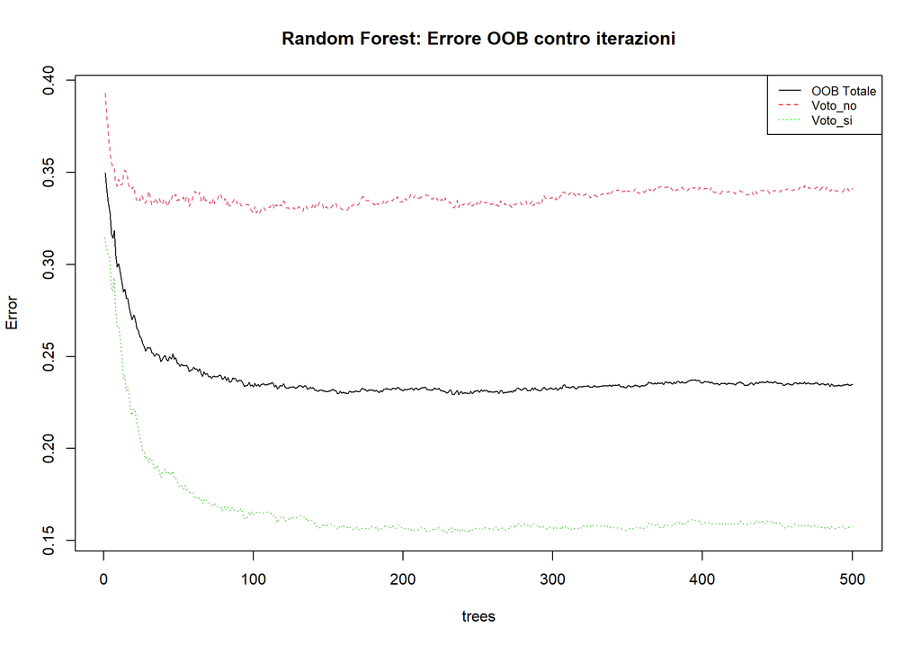

```r
plot(randomf, main = 'Random Forest: Errore OOB contro iterazioni')
legend("topright",
       legend = c("OOB Totale", "Voto_no", "Voto_si"),
       col = c("black", "red", "green"),
       lty = 1:3,
       cex = 0.8)
```

Il grafico mostra come l’errore OOB (*Out-of-Bag Error Rate*) evolve al crescere del numero di alberi. Tutte e tre le curve, ovvero l’errore medio complessivo (linea nera), quello per i comuni che hanno votato *no* (Voto_no, rossa) e quello per i comuni che hanno votato *sì* (Voto_si, verde), scendono rapidamente nei primi 100 alberi e si stabilizzano intorno ai 150, confermando che 500 alberi sono ampiamente sufficienti. Il modello predice meglio i comuni del *sì*, con un errore che si assesta intorno al 15%, mentre per i comuni del *no* rimane più alto, attorno al 33%: la classe negativa risulta strutturalmente più difficile da predire.

```r
pred_rf <- predict(randomf, newdata = tst_data, type = 'class')
matrix_rf <- table(pred_rf, tst_lable)
calc_metrics(matrix_rf)
```

```
##   Accuracy Sensitivity Specificity Precision
## 1    0.775       0.847       0.678     0.778
```

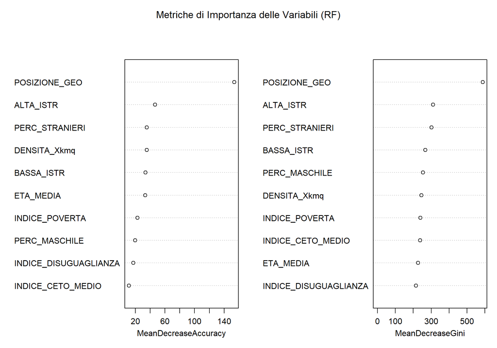

```r
varImpPlot(randomf, main = 'Metriche di Importanza delle Variabili (RF)')
```

Il Variable Importance plot mostra, per ciascuna variabile, quanto essa contribuisce alle predizioni del modello; misurato secondo due criteri complementari: la riduzione media dell’accuratezza (*MeanDecreaseAccuracy*) e la riduzione media dell’impurità di Gini (*MeanDecreaseGini*). Le variabili sono ordinate dall’alto verso il basso in senso decrescente di importanza.

**POSIZIONE_GEO** risulta di gran lunga il predittore più rilevante secondo entrambe le metriche, con un distacco netto rispetto a tutte le altre variabili. Questo indica che la collocazione geografica del comune è il fattore che, più di ogni altro, permette al modello di separare correttamente le due classi.

## 4.4 XAI e il Modello Surrogato

Quando le performance di un modello black-box sono troppo buone per essere abbandonate, ma la spiegabilità è un requisito, comunicativo o interpretativo si ricorre all’**XAI** (*eXplainable Artificial Intelligence*). Questa branca offre tecniche per ricostruire, almeno parzialmente, la logica decisionale di modelli complessi.

Il metodo qui adottato è il **Modello Surrogato Globale**: si addestra un modello semplice e interpretabile (un albero `rpart`) non per prevedere l’esito referendario reale, ma per *imitare* le previsioni prodotte dalla Random Forest. Il surrogato non vede mai la ground truth la sua variabile risposta è l’output della foresta. Se il surrogato riesce ad approssimare bene le decisioni della Random Forest con poche regole leggibili, quelle regole possono essere usate come proxy delle scelte della foresta stessa.

```r
library(rpart)
library(rpart.plot)

dati_surrogato <- tst_data
dati_surrogato$SI_NO <- NULL
dati_surrogato$PREVISIONE_RF <- pred_rf
```

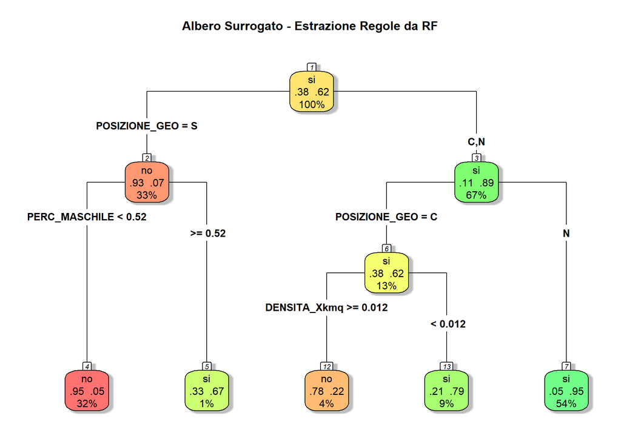

```r
albero_surrogato <- rpart(PREVISIONE_RF ~ ., data = dati_surrogato, method = "class")

rpart.plot(albero_surrogato, type = 4, extra = 104, box.palette = "RdYlGn",
           shadow.col = "gray", nn = TRUE,
           main = "Albero Surrogato - Estrazione Regole da RF")
```

> **Nota**: L’albero surrogato è una rappresentazione ad albero di decisione addestrata non sui dati originali, ma sulle *predizioni* del Random Forest. Ogni nodo interno contiene la variabile e la soglia usate per dividere le osservazioni, mentre ogni nodo foglia riporta tre informazioni: la classe predetta (*sì* o *no*), la distribuzione di probabilità tra le due classi (es. `.05 .95`) e la percentuale di osservazioni del campione che ricade in quel nodo. Il colore del riquadro riflette la classe dominante: verde per *sì*, rosso per *no*, giallo/arancio per nodi ancora incerti. L’albero si legge dall’alto verso il basso seguendo i rami: a sinistra si va quando la condizione del nodo è verificata, a destra quando non lo è.

L’albero surrogato riproduce in modo abbastanza fedele il comportamento del Random Forest e permette di capire quali variabili guidano le decisioni. Alla radice compare **POSIZIONE_GEO**, a indicare che la dimensione territoriale è il fattore più rilevante.

Nel complesso emerge una struttura interpretabile: prima conta la geografia, poi entrano in gioco le caratteristiche sociodemografiche del territorio. Va comunque tenuto presente che si tratta di una semplificazione: l’albero rende leggibile il modello, ma non cattura tutte le relazioni più complesse che la foresta originale è in grado di apprendere.

# 5. Conclusioni

Il progetto ha messo alla prova un ventaglio di tecniche di classificazione su un problema reale e non banale: prevedere l’esito del referendum 2026 a livello comunale a partire da caratteristiche strutturali del territorio.

Il risultato che emerge con più forza è la **centralità della geografia**. La variabile `POSIZIONE_GEO` domina tutti i modelli, parametrici e non parametrici, senza le variabili politiche storiche. Non si tratta di un artefatto tecnico: riflette una realtà ben documentata nella letteratura sul comportamento di voto italiano, dove Nord e Sud mantengono orientamenti politici strutturalmente divergenti che nessuna variabile demografica riesce a spiegare completamente in autonomia.

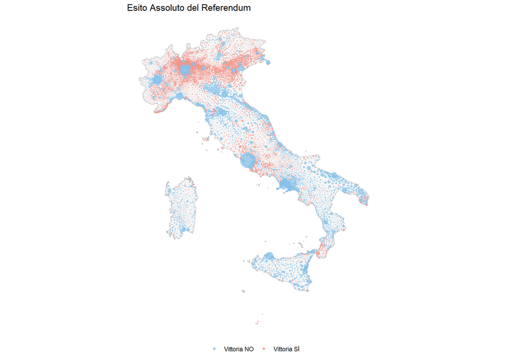

Geografia dell’esito elettorale pesato per popolazione residente

Il grafico in mappa sintetizza visivamente un interessante paradosso sociopolitico: sebbene il fronte del **SÌ** abbia inequivocabilmente trionfato nel numero assoluto di comuni sul tabellone , ha subìto una sconfitta nel numero reale di schede votanti finali. Il motivo è nel contrasto tra espansione territoriale e calibro demografico: la prevalenza del SÌ è frammentata e dispersa in migliaia di plessi comunali demograficamente irrilevanti o minuscoli.

Il secondo risultato rilevante riguarda il **peso dell’inerzia elettorale**. Quando si include `PERC_SI_EL22`, il voto politico del 2022 assorbe quasi tutto il segnale predittivo, relegando le variabili demografiche a un ruolo marginale. Il referendum 2026 è stato, in larga misura, un referendum sull’identità politica preesistente non una valutazione autonoma del merito della riforma.

In sintesi, il quadro che emerge è coerente: l’Italia vota seguendo linee geografiche e storiche profonde, che i modelli demografici riescono a catturare ma solo parzialmente, e sempre con l’ombra della posizione sul territorio come variabile di contesto dominante.

# 6. References

James, G., Witten, D., Hastie, T. & Tibshirani, R. (2021). *An Introduction to Statistical Learning: with Applications in R*. Springer Texts in Statistics. Springer, 2nd ed.

Meinshausen, N. (2007). Relaxed Lasso. *Computational Statistics & Data Analysis*, 52(1), 374–393.